# PracticalML_project

Eric Zhang

July 23, 2017

## Introduction

Using devices such as Jawbone Up, Nike FuelBand, and Fitbit it is now possible to collect a large amount of data about personal activity relatively inexpensively. These type of devices are part of the quantified self movement - a group of enthusiasts who take measurements about themselves regularly to improve their health, to find patterns in their behavior, or because they are tech geeks. One thing that people regularly do is quantify how much of a particular activity they do, but they rarely quantify how well they do it. In this project, we are going to use data from accelerometers on the belt, forearm, arm, and dumbell of 6 participants. They were asked to perform barbell lifts correctly and incorrectly in 5 different ways.

## Data preparation and clean up

Cleaning dataset follows two criteria: 1. Missing data is not going to fit in the model. Therefore, any column with missing data will be excluded. 2. As indicated in the introduction part, only data from accelerometers on the belt, forearm, arm, and dumbell are used for machine learning.

```r
# we do not need columns with many missing data
fun <- function(x){sum(is.na(x))}
count <- sapply(training, fun)
complete <- training[, count<1]

# get accelarator related columns and use them plut 'classe' to get the train dataset
acc_ind <- grep("arm|dumbbell|forearm|belt", names(complete),value = T)
acc_train <- select(complete, acc_ind, classe)
acc_ind2 <- grep("kurtosis|skewness|amplitude|max|min", names(acc_train), value = T)
acc_train <- select(acc_train, -one_of(acc_ind2))
```

## Model building and cross validation

```r
smp_size <- floor(0.75 * nrow(acc_train))
set.seed(123)
train_ind <- sample(seq_len(nrow(acc_train)), size = smp_size)
training <- acc_train[train_ind, ]
validation <- acc_train[-train_ind, ]

rf_model <- randomForest(factor(classe)~ ., data=training)
pred <- predict(rf_model, validation)
confusionMatrix(pred, validation$classe)
```

```
## Confusion Matrix and Statistics
##
##           Reference
## Prediction    A    B    C    D    E
##          A 1353    3    0    0    0
##          B    0  924    9    0    0
##          C    0    0  875    6    0
##          D    0    0    1  811    2
##          E    0    0    0    1  921
##
## Overall Statistics
##
##                Accuracy : 0.9955
##                  95% CI : (0.9932, 0.9972)
##     No Information Rate : 0.2758
##     P-Value [Acc > NIR] : < 2.2e-16
##
##                   Kappa : 0.9943
##  Mcnemar's Test P-Value : NA
##
## Statistics by Class:
##
##                      Class: A Class: B Class: C Class: D Class: E
## Sensitivity            1.0000   0.9968   0.9887   0.9914   0.9978
## Specificity            0.9992   0.9977   0.9985   0.9993   0.9997
## Pos Pred Value         0.9978   0.9904   0.9932   0.9963   0.9989
## Neg Pred Value         1.0000   0.9992   0.9975   0.9983   0.9995
## Prevalence             0.2758   0.1890   0.1804   0.1667   0.1881
## Detection Rate         0.2758   0.1883   0.1784   0.1653   0.1877
## Detection Prevalence   0.2764   0.1902   0.1796   0.1659   0.1879
## Balanced Accuracy      0.9996   0.9973   0.9936   0.9954   0.9988
```

As seen from the summary of the random forest model on the validation data, the model is very successful and resulted in an accuracy over 99.5%.

```r
test <- read.table("https://d396qusza40orc.cloudfront.net/predmachlearn/pml-testing.csv", sep = ',', header = TRUE)
test <- tbl_df(test)
# same feature elimination process as for the training set
count2 <- sapply(test, fun)
complete_test <- test[,count2<1]
acc_ind <- grep("arm|dumbbell|forearm|belt", names(complete_test), value=T)
acc_test <- select(complete_test, acc_ind)
# notice there is a "problem_id" column in the test data
```

## Appendix: Figures

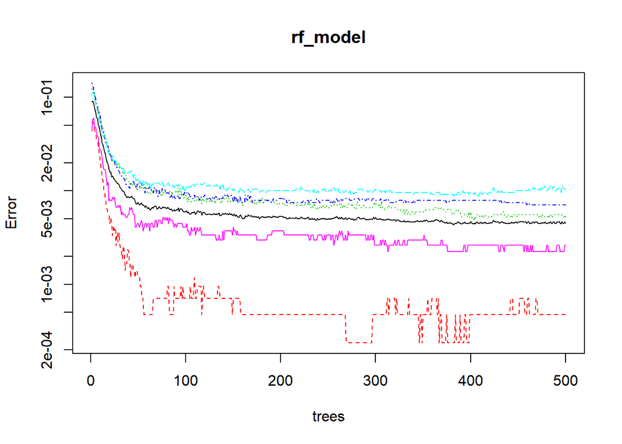

```
##                        Overall
## roll_belt            938.15584
## pitch_belt           519.64142
## yaw_belt             672.49865
## total_accel_belt     156.57551
## gyros_belt_x          74.15360
## gyros_belt_y          84.57887
## gyros_belt_z         236.46916
## accel_belt_x          90.26824
## accel_belt_y          92.49148
## accel_belt_z         293.27933
## magnet_belt_x        197.57585
## magnet_belt_y        297.66318
## magnet_belt_z        301.77788
## roll_arm             246.01930
## pitch_arm            136.84459
## yaw_arm              172.36805
## total_accel_arm       76.89289
## gyros_arm_x          102.48067
## gyros_arm_y          102.25393
## gyros_arm_z           45.89915
## accel_arm_x          177.17735
## accel_arm_y          111.66899
## accel_arm_z           97.09016
## magnet_arm_x         199.22042
## magnet_arm_y         167.93150
## magnet_arm_z         142.15439
## roll_dumbbell        313.16611
## pitch_dumbbell       139.67892
## yaw_dumbbell         196.91559
## total_accel_dumbbell 205.51245
## gyros_dumbbell_x      93.95236
## gyros_dumbbell_y     184.25045
## gyros_dumbbell_z      64.15868
## accel_dumbbell_x     193.33004
## accel_dumbbell_y     297.86097
## accel_dumbbell_z     253.91374
## magnet_dumbbell_x    369.01026
## magnet_dumbbell_y    525.02150
## magnet_dumbbell_z    569.61508
## roll_forearm         429.35447
## pitch_forearm        581.14487
## yaw_forearm          122.42430
## total_accel_forearm   80.79133
## gyros_forearm_x       58.07894
## gyros_forearm_y       91.76289
## gyros_forearm_z       64.38697
## accel_forearm_x      238.59933
## accel_forearm_y      102.52701
## accel_forearm_z      177.79951
## magnet_forearm_x     164.31357
## magnet_forearm_y     162.63882
## magnet_forearm_z     209.72937
```